# Featurization, Model Selection & Tuning Project

## Submitted by Utathya Ghosh

### Batch - AIML Online Jan 21-A

# TOTAL SCORE - 60

• DOMAIN: Semiconductor manufacturing process

• CONTEXT: A complex modern semiconductor manufacturing process is normally under constant surveillance via the monitoring of signals/variables collected from sensors and or process measurement points. However, not all of these signals are equally valuable in a specific monitoring system. The measured signals contain a combination of useful information, irrelevant information as well as noise. Engineers typically have a much larger number of signals than are actually required. If we consider each type of signal as a feature, then feature selection may be applied to identify the most relevant signals. The Process Engineers may then use these signals to determine key factors contributing to yield excursions downstream in the process. This will enable an increase in process throughput, decreased time to learning and reduce the per unit production costs. These signals can be used as features to predict the yield type. And by analysing and trying out different combinations of features, essential signals that are impacting the yield type can be identified.

• DATA DESCRIPTION: sensor-data.csv : (1567, 592) The data consists of 1567 examples each with 591 features. The dataset presented in this case represents a selection of such features where each example represents a single production entity with associated measured features and the labels represent a simple pass/fail yield for in house line testing. Target column “ –1” corresponds to a pass and “1” corresponds to a fail and the data time stamp is for that specific test point.

• PROJECT OBJECTIVE: We will build a classifier to predict the Pass/Fail yield of a particular process entity and analyse whether all the features are required to build the model or not

```python
import pandas as pd
import numpy as np
import datetime as dt
from sklearn.impute import SimpleImputer
from sklearn.neighbors import KNeighborsRegressor
from scipy.stats import zscore
import seaborn as sns
from matplotlib import pyplot as plt
from scipy.stats import ttest_ind, shapiro
from sklearn.ensemble import ExtraTreesClassifier
import operator
from sklearn.preprocessing import StandardScaler
from sklearn.model_selection import train_test_split
from imblearn.over_sampling import SMOTE
from sklearn.decomposition import PCA
from sklearn.model_selection import GridSearchCV
from xgboost import XGBClassifier
from sklearn.utils import resample
from sklearn.metrics import accuracy_score, classification_report, confusion_matrix
from sklearn.linear_model import LogisticRegression
from sklearn.naive_bayes import GaussianNB
from sklearn.svm import SVC
from sklearn.tree import DecisionTreeClassifier
from sklearn.ensemble import RandomForestClassifier
from sklearn.model_selection import RandomizedSearchCV
from sklearn.pipeline import Pipeline

np.random.seed(42)
```

```python
# Creating a function which will return the list of features which has very few unique values
def unique_values(df):
    unq = []

    # Create the dataframe of feature name and the number of unique values
    for col in df.columns[:-1]:
        unq.append(len(np.unique(df[col])))

    # Seperate features with one unique value
    df_unq = pd.DataFrame(unq, index=df.columns[:-1])
    drop_list = list(df_unq[df_unq[0]<2].index)

    # Display features with two unique values
    for col in df_unq[df_unq[0]==2].index:
        print(col, " : ", np.unique(df[col], return_counts=True))

    # Add two unique values feature to drop list
    drop_list.extend(list(df_unq[df_unq[0]==2].index))
    return(drop_list)
```

```python
# Creating a function to remove outliers
def rem_outliers(df):
    # Looping through all continous features
    for col in list(df.iloc[:, :-1].columns):

        new = []

        # Calculating upper and lower bounds
        q25, q75 = np.percentile(df[col], 25), np.percentile(df[col], 75)
        IQR = q75-q25
        threshold=IQR*1.5
        lower, upper = q25 - threshold, q75 + threshold

        # Calucalate mean
        mean = df[col].mean()
        # Creating a new list after Capping all outliers to upper or lower bound
        for i in df[col]:
            if i < lower:new.append(mean)
            elif i > upper:new.append(mean)
            else:new.append(i)

        # Changing column values to new list
        df[col] = new
    return(df)
```

```python
# Creating a function which will return required outputs after performing welch_ttest (unequal variance)
def ttest(x, y):
     # Welch's Test
    t, p = ttest_ind(x, y, equal_var = False)
    return(p)

def normal_test(df):
    # Initiate lists
    significant_list = []
    drop_list = []

    # Performing Welch's t test on Pass and Fail groups for all independent variables
    # Running a for loop to extract each feature name individually
    for col in df.columns[:-1]:
        # Creating 2 groups based on Dependent variable labels 1 and not 1
        group1 = df[col][df["Pass/Fail"]==1]
        group2 = df[col][df["Pass/Fail"]!=1]

        # If Shapiro test clears both groups (Confidence of 90%) then perform welch test else add to drop list
        if (shapiro(group1)[1]>0.1) and (shapiro(group2)[1]>0.1):
            # Calculate p value to check if mean is significantly different
            p = ttest(group1, group2)

            # If p is significant at 90% confidence then add feature to significant list
            if p < 0.1:
                significant_list.append(col)
        else:
            # Add to drop list if either group is not normally distributed
            drop_list.append(col)
    return(drop_list, significant_list)
```

```python
# Create a function which display Important features and also returns a list of important features
def imp_features(df):
    # create an instance for tree feature selection
    tree_clf = ExtraTreesClassifier(random_state=42)

    # first create arrays holding input and output data
    x_train = df_signal.drop("Pass/Fail", axis=1)
    y = df_signal['Pass/Fail'].replace({-1: 0})

    # fit the model
    tree_clf.fit(x_train, y)

    # Preparing variables
    importances = tree_clf.feature_importances_
    feature_names = x_train.columns
    feature_imp_dict = dict(zip(feature_names, importances))
    sorted_features = sorted(feature_imp_dict.items(), key=operator.itemgetter(1), reverse=True)
    indices = np.argsort(importances)[::-1]

    # Print the feature ranking (Top 20)
    print("Feature ranking:")
    for f in range(20):
        print("feature %d : %s (%f)" % (indices[f], sorted_features[f][0], sorted_features[f][1]))

    # Plot the top 100 feature importances of the forest
    plt.figure(figsize = (20,20))
    plt.title("Feature importances")
    plt.bar(range(len(x_train.columns)), importances[indices],
           color="r", align="center")
    plt.xticks(range(len(x_train.columns)), sorted_features, rotation=90)
    plt.xlim([-1, 100])
    plt.show()

    return(feature_imp_dict)
```

Steps and tasks: [ Total Score: 60 points]

#### 1. Import and explore the data.

```python
# Load csv file into a dataframe
df_signal = pd.read_csv("signal-data.csv")

# Display Shape and size of df_signal dataframe
print("Shape of Signal csv file :", df_signal.shape)
print("Size of Signal csv file :", df_signal.size)
```

```
Shape of Signal csv file : (1567, 592)
Size of Signal csv file : 927664
```

#### 2. Data cleansing:

##### • Missing value treatment.

```python
# Display relevant information
print("Number of columns in dataset  : ", len(df_signal.isnull().any()))
print("Columns with at least one Null: ", sum(df_signal.isnull().any()))
print("Rows with at least one Null   : ", sum(df_signal.isnull().any(axis=1)))
print("Columns that are int or float : ", len(df_signal.select_dtypes(include=['int64','float64']).columns))
print("Columns which are object type : ", len(df_signal.select_dtypes(include=['object']).columns))
```

```
Number of columns in dataset  :  592
Columns with at least one Null:  538
Rows with at least one Null   :  1567
Columns that are int or float :  591
Columns which are object type :  1
```

###### Powered by the observation that 538 columns out of 592 have missing data in them and 1567 rows have at least one null value in them. We can safely ignore the choice of dropping rows with missing values.

###### Moving on from the previous observations we decide to impute the missing values. The quick approach would be to impute the missing data with mean values.

###### Before Imputing however we will convert Time Column to more relevant columns

```python
df_signal.insert(1, "day", pd.to_datetime(df_signal["Time"]).dt.day)
df_signal.insert(1, "month", pd.to_datetime(df_signal["Time"]).dt.month)
df_signal.insert(1, "hour", pd.to_datetime(df_signal["Time"]).dt.hour)
df_signal.insert(1, "minute", pd.to_datetime(df_signal["Time"]).dt.minute)
df_signal.insert(1, "weekday", pd.to_datetime(df_signal["Time"]).dt.weekday)
df_signal.insert(1, "week", pd.to_datetime(df_signal["Time"]).dt.isocalendar().week.astype('int64'))
```

```python
# Instantiate Imputer object
imputer = SimpleImputer()

# Transform null values to mean of the feature
df_signal.iloc[:, 1:-1] = imputer.fit_transform(df_signal.iloc[:, 1:-1])

# Verify that all null values have been handled
print(sum(df_signal.isnull().any()))

# Quick look at the dataset
df_signal
```

```
0
```

|  | Time | week | weekday | minute | hour | month | day | 0 | 1 | 2 | ... | 581 | 582 | 583 | 584 | 585 | 586 | 587 | 588 | 589 | Pass/Fail |
| --- | --- | --- | --- | --- | --- | --- | --- | --- | --- | --- | --- | --- | --- | --- | --- | --- | --- | --- | --- | --- | --- |
| 0 | 2008-07-19 11:55:00 | 29.0 | 5.0 | 55.0 | 11.0 | 7.0 | 19.0 | 3030.93 | 2564.00 | 2187.7333 | ... | 97.934373 | 0.5005 | 0.0118 | 0.0035 | 2.3630 | 0.021458 | 0.016475 | 0.005283 | 99.670066 | -1 |
| 1 | 2008-07-19 12:32:00 | 29.0 | 5.0 | 32.0 | 12.0 | 7.0 | 19.0 | 3095.78 | 2465.14 | 2230.4222 | ... | 208.204500 | 0.5019 | 0.0223 | 0.0055 | 4.4447 | 0.009600 | 0.020100 | 0.006000 | 208.204500 | -1 |
| 2 | 2008-07-19 13:17:00 | 29.0 | 5.0 | 17.0 | 13.0 | 7.0 | 19.0 | 2932.61 | 2559.94 | 2186.4111 | ... | 82.860200 | 0.4958 | 0.0157 | 0.0039 | 3.1745 | 0.058400 | 0.048400 | 0.014800 | 82.860200 | 1 |
| 3 | 2008-07-19 14:43:00 | 29.0 | 5.0 | 43.0 | 14.0 | 7.0 | 19.0 | 2988.72 | 2479.90 | 2199.0333 | ... | 73.843200 | 0.4990 | 0.0103 | 0.0025 | 2.0544 | 0.020200 | 0.014900 | 0.004400 | 73.843200 | -1 |
| 4 | 2008-07-19 15:22:00 | 29.0 | 5.0 | 22.0 | 15.0 | 7.0 | 19.0 | 3032.24 | 2502.87 | 2233.3667 | ... | 97.934373 | 0.4800 | 0.4766 | 0.1045 | 99.3032 | 0.020200 | 0.014900 | 0.004400 | 73.843200 | -1 |
| ... | ... | ... | ... | ... | ... | ... | ... | ... | ... | ... | ... | ... | ... | ... | ... | ... | ... | ... | ... | ... | ... |
| 1562 | 2008-10-16 15:13:00 | 42.0 | 3.0 | 13.0 | 15.0 | 10.0 | 16.0 | 2899.41 | 2464.36 | 2179.7333 | ... | 203.172000 | 0.4988 | 0.0143 | 0.0039 | 2.8669 | 0.006800 | 0.013800 | 0.004700 | 203.172000 | -1 |
| 1563 | 2008-10-16 20:49:00 | 42.0 | 3.0 | 49.0 | 20.0 | 10.0 | 16.0 | 3052.31 | 2522.55 | 2198.5667 | ... | 97.934373 | 0.4975 | 0.0131 | 0.0036 | 2.6238 | 0.006800 | 0.013800 | 0.004700 | 203.172000 | -1 |
| 1564 | 2008-10-17 05:26:00 | 42.0 | 4.0 | 26.0 | 5.0 | 10.0 | 17.0 | 2978.81 | 2379.78 | 2206.3000 | ... | 43.523100 | 0.4987 | 0.0153 | 0.0041 | 3.0590 | 0.019700 | 0.008600 | 0.002500 | 43.523100 | -1 |
| 1565 | 2008-10-17 06:01:00 | 42.0 | 4.0 | 1.0 | 6.0 | 10.0 | 17.0 | 2894.92 | 2532.01 | 2177.0333 | ... | 93.494100 | 0.5004 | 0.0178 | 0.0038 | 3.5662 | 0.026200 | 0.024500 | 0.007500 | 93.494100 | -1 |
| 1566 | 2008-10-17 06:07:00 | 42.0 | 4.0 | 7.0 | 6.0 | 10.0 | 17.0 | 2944.92 | 2450.76 | 2195.4444 | ... | 137.784400 | 0.4987 | 0.0181 | 0.0040 | 3.6275 | 0.011700 | 0.016200 | 0.004500 | 137.784400 | -1 |

1567 rows × 598 columns

##### • Drop attribute/s if required using relevant functional knowledge.

###### In other situations Time can be useful column, here since we have already extracted its' more important aspects we can drop Time column

```python
# Drop unuseful column
try:
    df_signal.drop("Time", axis=1, inplace=True)
except:
    print("Time attribute is already dropped")
```

###### From experience we know that there will be more attributes which might be deemed droppable but we will do it after more information is extracted during EDA.

##### • Make all relevant modifications on the data using both functional/logical reasoning/assumptions.

```python
# Making 1 the desired result which is pass and converting -1 to 0 which is Fail
df_signal["Pass/Fail"] = df_signal["Pass/Fail"].replace({-1: 0})
```

###### From experience we know that there will be more relevant modifications that may need to be done but we will do it after more information is extracted during EDA.

#### 3. Data analysis & visualisation:

##### • Perform detailed relevant statistical analysis on the data.

```python
# Loop to count unique value of each column
for col in df_signal.columns:
    print(col, len(np.unique(df_signal[col])))
```

```
week 25
weekday 7
minute 60
hour 24
month 12
day 22
0 1521
1 1505
2 508
3 519
4 504
5 1
6 511
7 90
8 1209
```

[output cut: 582 more lines]

###### We can see that many columns are have very few unique values. Such columns are useless, specially the ones which have only one unique value, and in most cases when it has only two unique values.

```python
# Creating a drop least for only one or two unique values
drop_list = unique_values(df_signal)
```

```python
# Dropping values in drop list
df_signal.drop(drop_list, axis=1, inplace=True)

# Performing shapiro and signifiacance test
drop_list, significance_list = normal_test(df_signal)
```

```python
print("Out of %d independent columns, %d columns are not normally distributed"
      %(df_signal.iloc[:, :-1].shape[1], len(drop_list)))
```

```
Out of 480 independent columns, 479 columns are not normally distributed
```

###### With such few columns which are normally distributed it is pointless to check signifance at this point of time. We will keep that work for the future.

###### Let's look at the situation with outliers

```python
# Initailising
idx_list = []
outliers = {}

# Looping through all continous features
for col in list(df_signal.iloc[:, :-1].columns):

    # checking count of outliers.
    q25, q75 = np.percentile(df_signal[col], 25), np.percentile(df_signal[col], 75)
    IQR = q75-q25
    threshold=IQR*1.5
    lower, upper = q25 - threshold, q75 + threshold

    # Adding information to outliers list
    outliers[col] = [lower,
                     len([i for i in df_signal[col] if i < lower]),
                     upper,
                     len([i for i in df_signal[col] if i > upper])]

    # Creating list of indexes which are outliers
    for idx in df_signal[col].index:
        if df_signal.loc[idx, col] < lower:idx_list.append(idx)
        elif df_signal.loc[idx, col] > upper:idx_list.append(idx)

#     # Removing duplicates from index list
#     idx_list = list(set(idx_list))
```

```python
# # Check Index list length
print("Number of rows lost if we drop outliers : ", len(set(idx_list)))

# Create a dataframe with outlier information
pd.DataFrame(outliers, index=["lower", "outlier_l", "upper", "outlier_u"])
```

```
Number of rows lost if we drop outliers :  1567
```

|  | week | weekday | minute | hour | month | day | 0 | 1 | 2 | 3 | ... | 580 | 581 | 582 | 583 | 584 | 585 | 586 | 587 | 588 | 589 |
| --- | --- | --- | --- | --- | --- | --- | --- | --- | --- | --- | --- | --- | --- | --- | --- | --- | --- | --- | --- | --- | --- |
| lower | 11.5 | -5.0 | -30.0 | -12.0 | 4.0 | -9.5 | 2831.8525 | 2324.095 | 2125.666625 | 324.45965 | ... | 0.005396 | 81.972566 | 0.491225 | 0.00425 | 0.0016 | 0.823825 | -0.007775 | -0.00395 | -0.00135 | -61.20305 |
| outlier_l | 199.0 | 0.0 | 0.0 | 0.0 | 199.0 | 0.0 | 10.0000 | 48.000 | 18.000000 | 1.00000 | ... | 379.000000 | 358.000000 | 4.000000 | 0.00000 | 0.0000 | 0.000000 | 1.000000 | 0.00000 | 0.00000 | 0.00000 |
| upper | 55.5 | 11.0 | 90.0 | 36.0 | 12.0 | 42.5 | 3191.3525 | 2667.535 | 2273.488825 | 2349.59605 | ... | 0.005396 | 107.511457 | 0.509025 | 0.02385 | 0.0056 | 4.777625 | 0.048825 | 0.03485 | 0.01105 | 220.32135 |
| outlier_u | 0.0 | 0.0 | 0.0 | 0.0 | 0.0 | 0.0 | 41.0000 | 39.000 | 13.000000 | 50.00000 | ... | 239.000000 | 181.000000 | 7.000000 | 79.00000 | 56.0000 | 78.000000 | 31.000000 | 60.00000 | 65.00000 | 133.00000 |

4 rows × 480 columns

###### It is apparent from the information above that we cannot choose to drop outliers since we will end up dropping all records. So the next best thing is to either cap outliers or to change the outliers to mean values. Since we also know that most features are not normally distributed, also that some features have a lot of outliers. So we will not add to the problem with capping as it will create peaks at the tails. So the most acceptable bias is to change outlier values to the mean of the feature distribution.

###### Since a lot of columns have very high number of outliers. To add to that if we drop all outliers then we lose the entire dataset. Also since if we cap outliers then columns will have more than one peak and hence will not be normally distributed. Further more the target variable class is already imbalanced. Hence we will deal with outliers in two ways:-

###### First we will remove rows with the highest number of outliers, making sure we choose rows only from the dominant class of the target variables. We will use this method as much as possible towards achieving class balance.

###### The rest of the outliers we will change into the mean of the column. Since the number of columns affected by this will be much reduced from the earlier conditions, hence we will bias the dataset the least in this way.

```python
# Create an outliers dataframe which tracks how many outliers in each row
df_outliers = pd.DataFrame(np.unique(idx_list, return_counts=True), index=["idx", "freq"]).T

# Add target variable
df_outliers["Pass/Fail"] = df_signal["Pass/Fail"]

# Create a drop list based on undersampling dominant class
drop_list = df_outliers[df_outliers["Pass/Fail"] == 0].sort_values("freq", ascending=False).head(1069).index

# Drop records based on droplist
df_signal.drop(drop_list, inplace=True)
```

```python
# Checking dataset information
df_signal.shape
```

```
(498, 481)
```

###### More statistical tests will be done but we will do it after removing outliers.

##### • Perform a detailed univariate, bivariate and multivariate analysis with appropriate detailed comments after each analysis.

```python
# Display the dataset
df_signal
```

|  | week | weekday | minute | hour | month | day | 0 | 1 | 2 | 3 | ... | 581 | 582 | 583 | 584 | 585 | 586 | 587 | 588 | 589 | Pass/Fail |
| --- | --- | --- | --- | --- | --- | --- | --- | --- | --- | --- | --- | --- | --- | --- | --- | --- | --- | --- | --- | --- | --- |
| 2 | 29.0 | 5.0 | 17.0 | 13.0 | 7.0 | 19.0 | 2932.61 | 2559.94 | 2186.4111 | 1698.0172 | ... | 82.860200 | 0.4958 | 0.0157 | 0.0039 | 3.1745 | 0.0584 | 0.0484 | 0.0148 | 82.8602 | 1 |
| 6 | 29.0 | 5.0 | 44.0 | 19.0 | 7.0 | 19.0 | 3030.27 | 2430.12 | 2230.4222 | 1463.6606 | ... | 97.934373 | 0.5010 | 0.0143 | 0.0042 | 2.8515 | 0.0342 | 0.0151 | 0.0052 | 44.0077 | 0 |
| 10 | 29.0 | 5.0 | 57.0 | 21.0 | 7.0 | 19.0 | 2994.05 | 2548.21 | 2195.1222 | 1046.1468 | ... | 57.812200 | 0.4925 | 0.0158 | 0.0041 | 3.2115 | 0.0355 | 0.0205 | 0.0071 | 57.8122 | 1 |
| 11 | 29.0 | 5.0 | 52.0 | 22.0 | 7.0 | 19.0 | 2928.84 | 2479.40 | 2196.2111 | 1605.7578 | ... | 75.507700 | 0.4987 | 0.0427 | 0.0092 | 8.5646 | 0.0370 | 0.0279 | 0.0081 | 75.5077 | 1 |
| 14 | 30.0 | 0.0 | 53.0 | 11.0 | 7.0 | 21.0 | 2963.97 | 2629.48 | 2224.6222 | 947.7739 | ... | 142.908000 | 0.5077 | 0.0094 | 0.0026 | 1.8483 | 0.0202 | 0.0289 | 0.0084 | 142.9080 | 1 |
| ... | ... | ... | ... | ... | ... | ... | ... | ... | ... | ... | ... | ... | ... | ... | ... | ... | ... | ... | ... | ... | ... |
| 1438 | 37.0 | 2.0 | 34.0 | 4.0 | 9.0 | 10.0 | 2951.84 | 2477.13 | 2192.1889 | 1435.9611 | ... | 97.934373 | 0.4969 | 0.0118 | 0.0037 | 2.3773 | 0.0178 | 0.0120 | 0.0038 | 67.7994 | 1 |
| 1443 | 37.0 | 2.0 | 55.0 | 15.0 | 9.0 | 10.0 | 3173.18 | 2428.64 | 2209.4667 | 1556.3930 | ... | 88.152800 | 0.5021 | 0.0192 | 0.0041 | 3.8289 | 0.0281 | 0.0247 | 0.0075 | 88.1528 | 1 |
| 1447 | 41.0 | 4.0 | 53.0 | 10.0 | 10.0 | 10.0 | 2949.12 | 2553.24 | 2176.8000 | 1461.4374 | ... | 97.934373 | 0.5031 | 0.0111 | 0.0033 | 2.2148 | 0.0250 | 0.0088 | 0.0029 | 35.1564 | 0 |
| 1496 | 42.0 | 1.0 | 21.0 | 3.0 | 10.0 | 14.0 | 3073.57 | 2528.59 | 2217.4111 | 1032.2836 | ... | 97.934373 | 0.4950 | 0.0115 | 0.0028 | 2.3235 | 0.0138 | 0.0162 | 0.0047 | 117.7603 | 0 |
| 1519 | 42.0 | 2.0 | 42.0 | 2.0 | 10.0 | 15.0 | 2903.34 | 2585.48 | 2196.1111 | 1472.6400 | ... | 85.312200 | 0.4979 | 0.0176 | 0.0040 | 3.5250 | 0.0157 | 0.0134 | 0.0043 | 85.3122 | 1 |

498 rows × 481 columns

###### Let's have a quick look at the outliers through boxplots

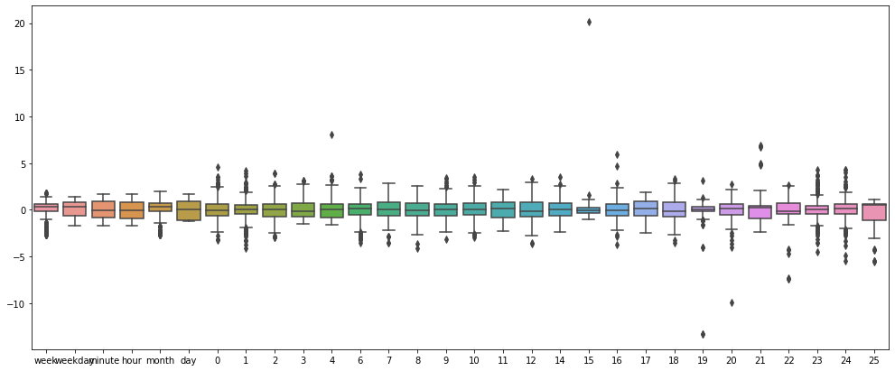

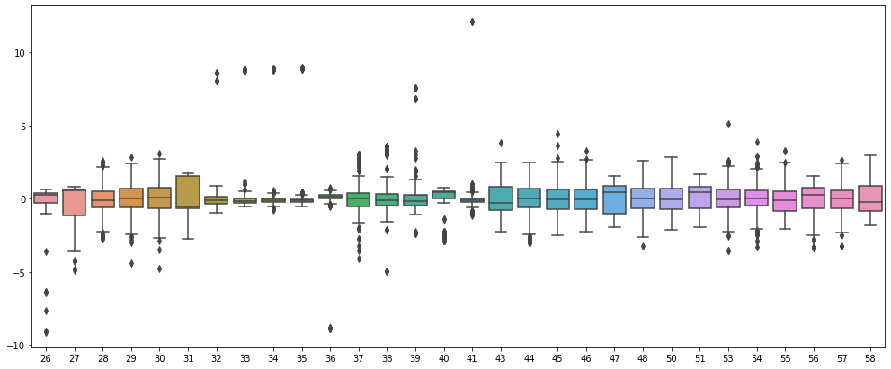

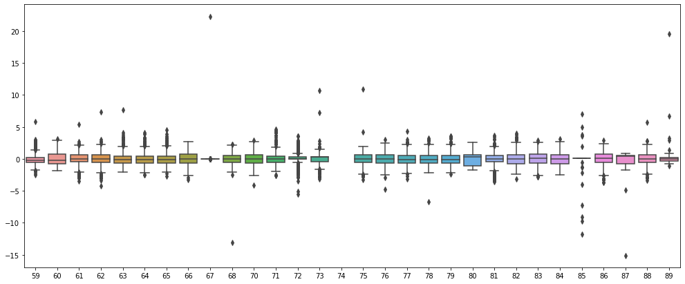

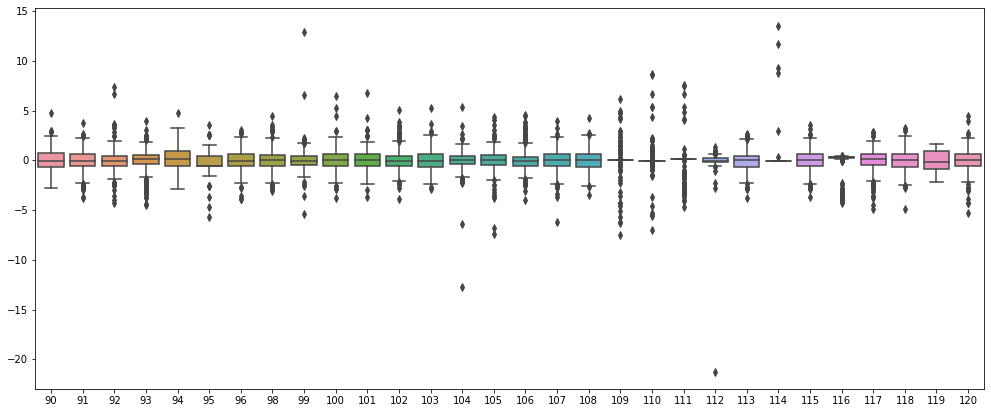

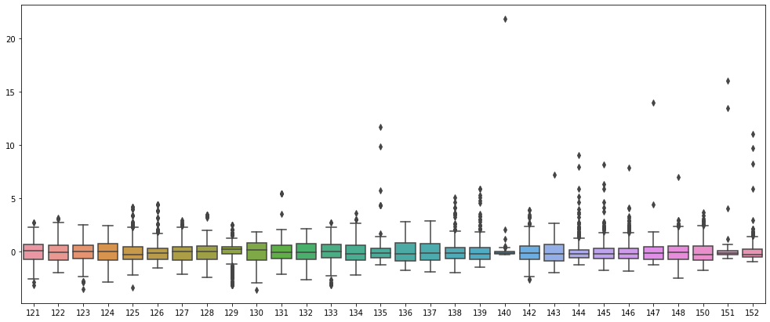

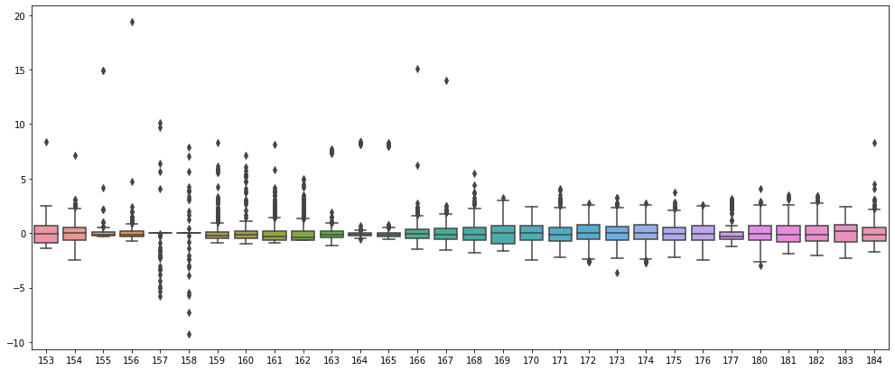

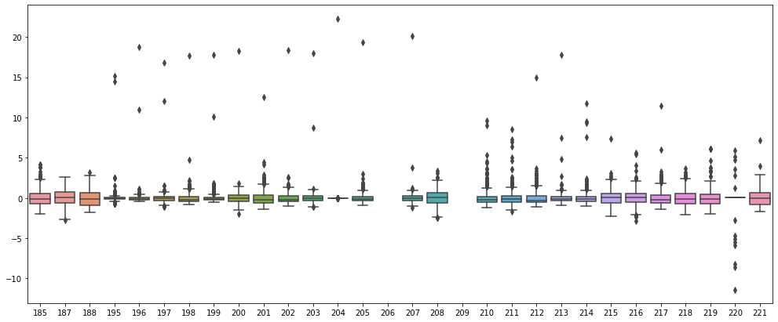

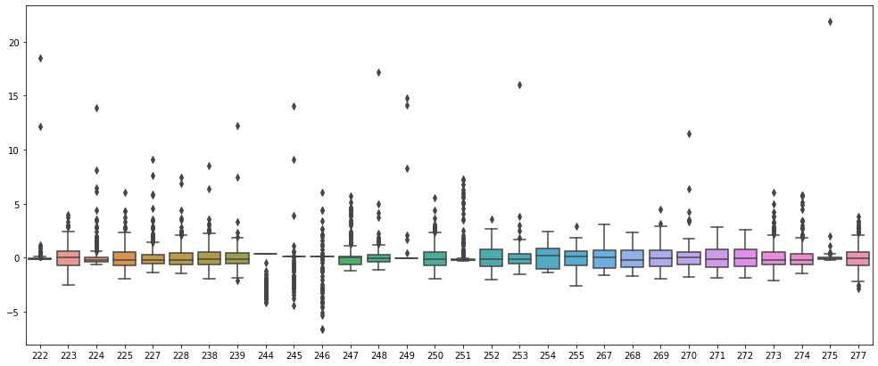

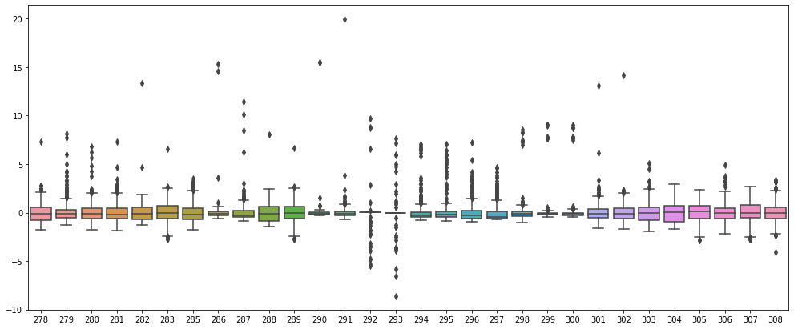

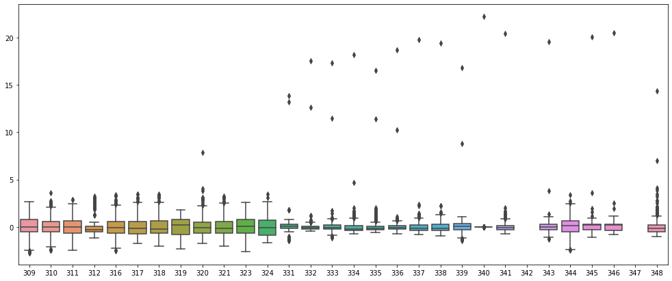

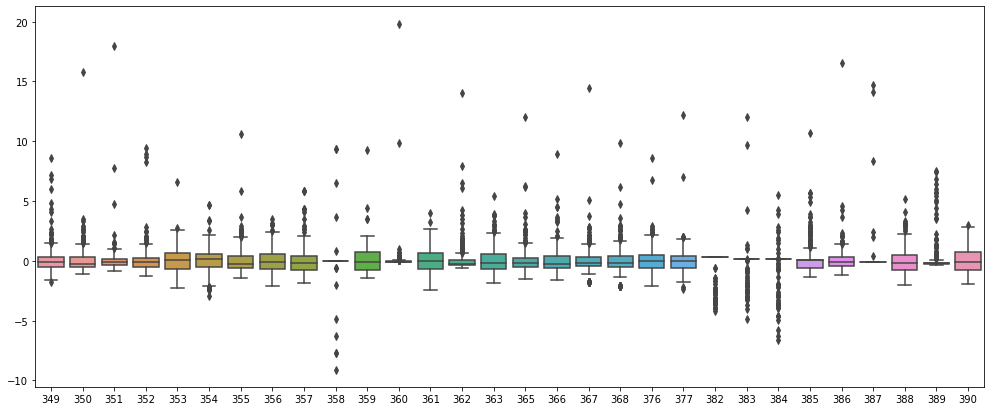

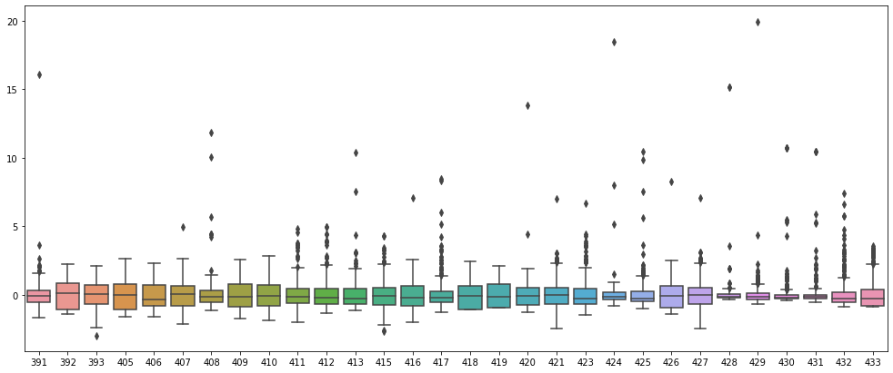

[4 more figures not shown]

```python
# Calculate the number of rows
rng = int(df_signal.shape[1]/30)

# run Loop
for mul in range(rng):
    f, axes = plt.subplots(1, figsize=(17,7))
    sns.boxplot(data=df_signal.iloc[:, mul*30:(mul+1)*30].apply(zscore))
```

###### Now let us look at Extra trees classifier to see which features are relevant to the target variable

```
Feature ranking:
feature 321 : 382 (0.016239)
feature 417 : 516 (0.015141)
feature 218 : 244 (0.015061)
feature 60 : 59 (0.013214)
feature 322 : 383 (0.008703)
feature 219 : 245 (0.008248)
feature 110 : 111 (0.007497)
feature 66 : 65 (0.006370)
feature 418 : 517 (0.006294)
feature 415 : 510 (0.006073)
feature 161 : 164 (0.005959)
feature 362 : 436 (0.005765)
feature 261 : 300 (0.005551)
feature 459 : 569 (0.005518)
feature 221 : 247 (0.005479)
feature 65 : 64 (0.005453)
feature 30 : 26 (0.005386)
feature 208 : 220 (0.005219)
feature 160 : 163 (0.005158)
feature 260 : 299 (0.005090)
```

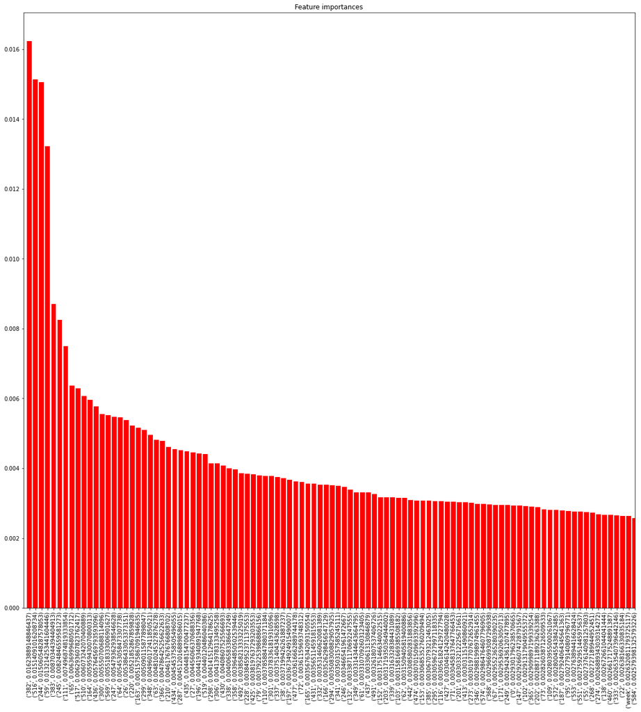

```python
# Create important feature list
feature_imp_dict = imp_features(df_signal)
```

```python
# Turn important features to dataframe
df_imp = pd.DataFrame(feature_imp_dict, index=["importance"]).T.sort_values("importance", ascending=False)

# Create a column to record the cumulative sum
df_imp["cumulative"] = df_imp.cumsum()
df_imp
```

|  | importance | cumulative |
| --- | --- | --- |
| 382 | 0.016239 | 0.016239 |
| 516 | 0.015141 | 0.031380 |
| 244 | 0.015061 | 0.046440 |
| 59 | 0.013214 | 0.059655 |
| 383 | 0.008703 | 0.068358 |
| ... | ... | ... |
| 209 | 0.000000 | 1.000000 |
| 206 | 0.000000 | 1.000000 |
| 347 | 0.000000 | 1.000000 |
| 342 | 0.000000 | 1.000000 |
| 478 | 0.000000 | 1.000000 |

480 rows × 2 columns

###### Finally with all our information let us finish treating outliers and complete our statistics tests

```python
# Treat outliers
df_signal = rem_outliers(df_signal)
```

```python
# Remove columns where unique values have become low
drop_list = unique_values(df_signal)
```

```
85  :  (array([0.11275695, 0.11278319]), array([ 14, 484], dtype=int64))
109  :  (array([0.97999206, 0.97999253]), array([ 49, 449], dtype=int64))
110  :  (array([101.31825282, 101.34262955]), array([449,  49], dtype=int64))
111  :  (array([231.76290529, 231.81889763]), array([ 49, 449], dtype=int64))
114  :  (array([0.        , 0.00015843]), array([492,   6], dtype=int64))
157  :  (array([0.04686576, 0.04710435]), array([ 27, 471], dtype=int64))
158  :  (array([1039.65073768, 1040.42991576]), array([471,  27], dtype=int64))
220  :  (array([0.00919761, 0.00921283]), array([ 14, 484], dtype=int64))
244  :  (array([0.00539417, 0.00575501]), array([ 49, 449], dtype=int64))
245  :  (array([1.69467966, 1.72972332]), array([ 49, 449], dtype=int64))
246  :  (array([4.09621548, 4.14874189]), array([ 49, 449], dtype=int64))
249  :  (array([0.        , 0.00116847]), array([492,   6], dtype=int64))
292  :  (array([0.01442843, 0.01448696]), array([ 27, 471], dtype=int64))
293  :  (array([335.55115652, 335.8195653 ]), array([471,  27], dtype=int64))
358  :  (array([0.00244151, 0.00244292]), array([ 14, 484], dtype=int64))
```

[output cut: 17 more lines]

###### There seems to be no good reasons to save any features with two unique values. Hence continuing with droppping the featues

```python
# Dropping low unique values
df_signal.drop(drop_list, axis=1, inplace=True)
```

```python
# Running significance to normalised values
drop_list, significant_list = normal_test(pd.concat([df_signal.iloc[:, :-1].apply(zscore), df_signal.iloc[:, -1]], axis=1))
```

```python
len(drop_list)
```

```
398
```

###### Was hoping to see fewer columns which failed shapiro test but still we push on. :-)

```python
# Drop columns which are not normally distributed
df_signal.drop(drop_list, axis=1, inplace=True)

# Check size of significant list
len(significant_list)
```

```
5
```

```python
significant_list
```

```
['197', '336', '434', '452', '582']
```

###### Let us view the resultant dataset. We already completed our stats test and got the most significant list. Now let us close the EDA part by looking at Extra Trees Classifier to form an important list.

```python
# View the dataset
df_signal
```

|  | 8 | 9 | 20 | 29 | 62 | 68 | 70 | 75 | 76 | 83 | ... | 427 | 434 | 444 | 452 | 459 | 472 | 570 | 574 | 582 | Pass/Fail |
| --- | --- | --- | --- | --- | --- | --- | --- | --- | --- | --- | --- | --- | --- | --- | --- | --- | --- | --- | --- | --- | --- |
| 2 | 1.4436 | 0.0041 | 1.4123 | 2.3333 | 115.6273 | 145.8000 | 625.9636 | -0.0078 | -0.0326 | 7.104100 | ... | 4.258100 | 14.250300 | 0.8973 | 4.8795 | 2.804200 | 148.0287 | 535.024500 | 4.0923 | 0.4958 | 1 |
| 6 | 1.5816 | -0.0270 | 1.4067 | 2.4889 | 114.4564 | 152.3582 | 618.2745 | 0.0227 | -0.0132 | 8.412600 | ... | 3.921466 | 8.606900 | 0.8615 | 5.1876 | 2.915511 | 110.2830 | 532.447288 | 2.2019 | 0.5010 | 0 |
| 10 | 1.5144 | -0.0190 | 1.4195 | 1.9444 | 108.1191 | 144.5955 | 617.6045 | 0.0035 | -0.0530 | 7.490200 | ... | 3.921466 | 13.997547 | 0.8973 | 4.4107 | 3.034100 | 219.3969 | 532.176400 | 3.3618 | 0.4925 | 1 |
| 11 | 1.4690 | 0.0170 | 1.4210 | 2.0667 | 128.9618 | 144.1700 | 635.6382 | -0.0223 | -0.0947 | 6.638300 | ... | 6.443700 | 7.977800 | 0.8204 | 4.1797 | 3.597900 | 145.9369 | 533.746400 | 2.8659 | 0.4987 | 1 |
| 14 | 1.4474 | 0.0144 | 1.4029 | 2.4222 | 115.9182 | 150.1191 | 619.3500 | -0.0151 | -0.0617 | 7.344500 | ... | 2.843200 | 13.997547 | 0.9181 | 5.2329 | 3.057600 | 169.5462 | 532.644600 | 3.7724 | 0.5077 | 1 |
| ... | ... | ... | ... | ... | ... | ... | ... | ... | ... | ... | ... | ... | ... | ... | ... | ... | ... | ... | ... | ... | ... |
| 1438 | 1.4613 | -0.0027 | 1.4189 | 1.8667 | 120.6736 | 147.0582 | 618.2173 | -0.0076 | 0.0084 | 7.901800 | ... | 4.013100 | 13.997547 | 0.9021 | 4.5227 | 3.353000 | 127.0192 | 531.746400 | 3.1198 | 0.4969 | 1 |
| 1443 | 1.6073 | -0.0278 | 1.3878 | 2.0000 | 120.2427 | 142.9782 | 611.9545 | 0.0109 | -0.0001 | 6.576100 | ... | 3.781500 | 13.543500 | 0.7457 | 5.0602 | 3.083800 | 110.9767 | 533.136400 | 2.4138 | 0.5021 | 1 |
| 1447 | 1.5576 | -0.0205 | 1.4252 | 2.5778 | 121.1291 | 146.0273 | 616.0318 | 0.0105 | -0.0188 | 7.098500 | ... | 6.469500 | 13.005600 | 1.0417 | 6.4289 | 3.352400 | 122.0276 | 531.746400 | 3.1198 | 0.5031 | 0 |
| 1496 | 1.4234 | -0.0045 | 1.4000 | 2.4222 | 118.1664 | 149.1809 | 632.6700 | -0.0105 | 0.0047 | 7.589600 | ... | 1.841600 | 18.114700 | 0.9420 | 5.5573 | 3.824900 | 146.5067 | 532.447288 | 2.8447 | 0.4950 | 0 |
| 1519 | 1.5134 | 0.0036 | 1.4220 | 2.2444 | 115.3055 | 147.3445 | 613.7882 | -0.0309 | -0.0471 | 7.391159 | ... | 4.991700 | 13.131300 | 1.0831 | 5.8665 | 2.370800 | 117.9138 | 530.336400 | 2.9335 | 0.4979 | 1 |

498 rows × 45 columns

```
Feature ranking:
feature 42 : 574 (0.031534)
feature 38 : 452 (0.029716)
feature 24 : 197 (0.028716)
feature 43 : 582 (0.027781)
feature 31 : 336 (0.027364)
feature 2 : 20 (0.026692)
feature 25 : 200 (0.026491)
feature 6 : 70 (0.025594)
feature 40 : 472 (0.025132)
feature 1 : 9 (0.025036)
feature 23 : 187 (0.024869)
feature 30 : 301 (0.024848)
feature 28 : 283 (0.024192)
feature 36 : 434 (0.024182)
feature 4 : 62 (0.024112)
feature 27 : 223 (0.023621)
feature 39 : 459 (0.023046)
feature 10 : 88 (0.023014)
feature 33 : 361 (0.022484)
feature 3 : 29 (0.022002)
```

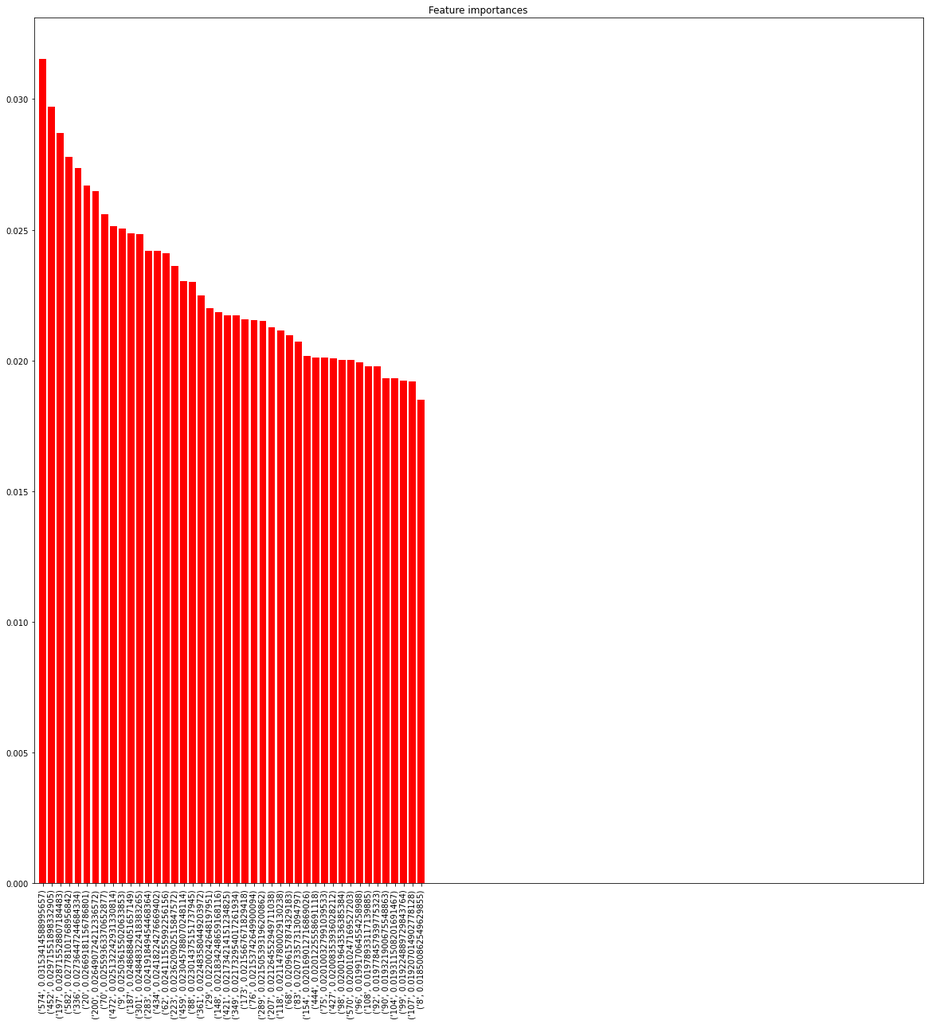

```python
# Create important feature list
feature_imp_dict = imp_features(df_signal)
```

```python
# Turn important features to dataframe
df_imp = pd.DataFrame(feature_imp_dict, index=["importance"]).T.sort_values("importance", ascending=False)

# Create a column to record the cumulative sum
df_imp["cumulative"] = df_imp.cumsum()
df_imp
```

|  | importance | cumulative |
| --- | --- | --- |
| 574 | 0.031534 | 0.031534 |
| 452 | 0.029716 | 0.061250 |
| 197 | 0.028716 | 0.089965 |
| 582 | 0.027781 | 0.117746 |
| 336 | 0.027364 | 0.145111 |
| 20 | 0.026692 | 0.171802 |
| 200 | 0.026491 | 0.198293 |
| 70 | 0.025594 | 0.223887 |
| 472 | 0.025132 | 0.249019 |
| 9 | 0.025036 | 0.274055 |
| 187 | 0.024869 | 0.298924 |
| 301 | 0.024848 | 0.323772 |
| 283 | 0.024192 | 0.347964 |
| 434 | 0.024182 | 0.372147 |
| 62 | 0.024112 | 0.396258 |
| 223 | 0.023621 | 0.419879 |
| 459 | 0.023046 | 0.442925 |
| 88 | 0.023014 | 0.465939 |
| 361 | 0.022484 | 0.488423 |
| 29 | 0.022002 | 0.510425 |
| 148 | 0.021834 | 0.532259 |
| 421 | 0.021734 | 0.553994 |
| 349 | 0.021733 | 0.575727 |
| 173 | 0.021567 | 0.597293 |
| 76 | 0.021537 | 0.618831 |
| 289 | 0.021505 | 0.640336 |
| 207 | 0.021265 | 0.661601 |
| 118 | 0.021148 | 0.682748 |
| 68 | 0.020962 | 0.703710 |
| 83 | 0.020734 | 0.724444 |
| 154 | 0.020169 | 0.744613 |
| 444 | 0.020123 | 0.764735 |
| 75 | 0.020100 | 0.784836 |
| 427 | 0.020084 | 0.804919 |
| 98 | 0.020020 | 0.824939 |
| 570 | 0.020010 | 0.844949 |
| 96 | 0.019917 | 0.864866 |
| 108 | 0.019789 | 0.884655 |
| 92 | 0.019778 | 0.904434 |
| 90 | 0.019322 | 0.923756 |
| 104 | 0.019312 | 0.943067 |
| 99 | 0.019225 | 0.962292 |
| 107 | 0.019207 | 0.981499 |
| 8 | 0.018501 | 1.000000 |

###### Finally using the significant list we will shorten the important list to the most important columns upto the point which completely contains all columns of the significant list. The resultant important list will be all the columns that will be used for building our models.

```python
# Use the significant list and locate the lowest positioned significant column name
df_imp.loc[df_imp["cumulative"] == df_imp.loc[significant_list, "cumulative"].max()]
```

|  | importance | cumulative |
| --- | --- | --- |
| 434 | 0.024182 | 0.372147 |

```python
# Repopulate the important list with all column names which are more important than least important significant list value
imp_list = list(df_imp.loc[:'434'].index)

# View the important list
imp_list
```

```
['574',
 '452',
 '197',
 '582',
 '336',
 '20',
 '200',
 '70',
 '472',
 '9',
 '187',
 '301',
 '283',
 '434']
```

###### This was the final step of our feature engineering jouney. The information derived in our EDA greatly reduced dimensions complexity. We managed to create a list of columns which are the combination of the most important and significant columns. Most importantly we have also handled outliers, null values and worked on class imbalance. A job well done till this point :-)

```python
# Display the size of the final important list
len(imp_list)
```

```
14
```

#### 4. Data pre-processing:

##### • Segregate predictors vs target attributes

```python
# Seperating dependent and independent variables
y = df_signal["Pass/Fail"]
X = df_signal.iloc[:, :-1]
```

##### • Check for target balancing and fix it if found imbalanced.

```
(array([0, 1], dtype=int64), array([394, 104], dtype=int64))
```

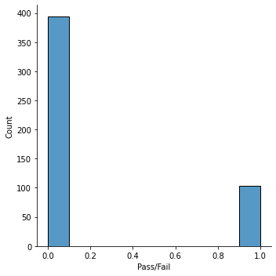

```python
# Class distribution
print(np.unique(y, return_counts=True))

# Class distribution visual
sns.displot(data=y, x=y)
```

###### Clearly there is still a class imbalance, but we will handle that after we split our dataset. So it will come later in a few steps.

##### • Perform train-test split and standardise the data or vice versa if required.

```python
# Scaling the required slice of dataset
scaler = StandardScaler()
X = pd.DataFrame(scaler.fit_transform(X[imp_list]), columns=X[imp_list].columns)

# setting up testing and training sets
X_train, X_val, y_train, y_val = train_test_split(X, y, test_size=0.4, random_state=42, stratify=y)
```

```python
# Using SMOTE to create new datas around actual data of minor class till a ratio of 1:1 between the 2 classes
sm = SMOTE(random_state=42, sampling_strategy=1.0)
X_train, y_train = sm.fit_resample(X_train, y_train)
X_val, y_val = sm.fit_resample(X_val, y_val)

# Resetting index of new groups for later convenience
X_train.reset_index(drop=True, inplace=True)
X_val.reset_index(drop=True, inplace=True)
y_train.reset_index(drop=True, inplace=True)
y_val.reset_index(drop=True, inplace=True)
```

##### • Check if the train and test data have similar statistical characteristics when compared with original data.

```
Feature ranking:
feature 42 : 574 (0.031534)
feature 38 : 452 (0.029716)
feature 24 : 197 (0.028716)
feature 43 : 582 (0.027781)
feature 31 : 336 (0.027364)
feature 2 : 20 (0.026692)
feature 25 : 200 (0.026491)
feature 6 : 70 (0.025594)
feature 40 : 472 (0.025132)
feature 1 : 9 (0.025036)
feature 23 : 187 (0.024869)
feature 30 : 301 (0.024848)
feature 28 : 283 (0.024192)
feature 36 : 434 (0.024182)
feature 4 : 62 (0.024112)
feature 27 : 223 (0.023621)
feature 39 : 459 (0.023046)
feature 10 : 88 (0.023014)
feature 33 : 361 (0.022484)
feature 3 : 29 (0.022002)
```

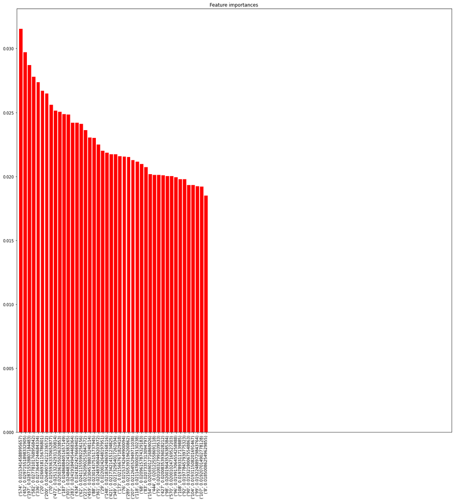

```python
feature_imp_dict = imp_features(pd.concat([X_train, y_train], axis=1))
```

```python
df_imp2 = pd.DataFrame(feature_imp_dict, index=["importance"]).T.sort_values("importance", ascending=False)
df_imp2["cumulative"] = df_imp2.cumsum()
```

```python
df_imp2.loc[df_imp["cumulative"] == df_imp2.loc[significant_list, "cumulative"].max()]
```

|  | importance | cumulative |
| --- | --- | --- |
| 434 | 0.024182 | 0.372147 |

```python
# Repopulate the important list with all column names which are more important than least important significant list value
imp2_list = list(df_imp.loc[:'434'].index)

# View the legnth of important list
len(list(df_imp2.loc[:'434'].index))
```

```
14
```

```python
# Original significant list
significant_list
```

```
['197', '336', '434', '452', '582']
```

```python
# Apply stats test on train sets
drop_list2, significant_list2 = normal_test(pd.concat([X_train, y_train], axis=1))

# Display intersection of old and new significant list
print(len(set(significant_list).intersection(set(significant_list2))))

# New significant list
significant_list2
```

```
0
```

```
[]
```

```python
# Check length of new drop_list
len(drop_list2)
```

```
12
```

###### Clearly original dataset and train dataset are not statistically the same. We have not checked the validation test set however, one of the splits not matching is good enough to tell us that splitting the dataset has created statistically different samples. So different samples are pointing to different populations. We will however go ahead with our analysis with this fact in mind.

#### 5. Model training, testing and tuning:

##### • Model training:

- Pick up a supervised learning model.
- Train the model.
- Use cross validation techniques. Hint: Use all CV techniques that you have learnt in the course.
- Apply hyper-parameter tuning techniques to get the best accuracy. Suggestion: Use all possible hyper parameter combinations to extract the best accuracies.
- Use any other technique/method which can enhance the model performance. Hint: Dimensionality reduction, attribute removal, standardisation/normalisation, target balancing etc.
- Display and explain the classification report in detail.
- Design a method of your own to check if the achieved train and test accuracies might change if a different sample population can lead to new train and test accuracies. Hint: You can use your concepts learnt under Applied Statistics module.
- Apply the above steps for all possible models that you have learnt so far.

###### The function in the cell below achieve the following:-

- Use cross validation techniques. Hint: Use all CV techniques that you have learnt in the course.
- Apply hyper-parameter tuning techniques to get the best accuracy. Suggestion: Use all possible hyper parameter combinations to extract the best accuracies.
- Design a method of your own to check if the achieved train and test accuracies might change if a different sample population can lead to new train and test accuracies. Hint: You can use your concepts learnt under Applied Statistics module.

```python
# Use cross validation techniques
# Apply hyper-parameter tuning techniques to get the best accuracy
def param_tuning(X, y, model, param, X_val, y_val):
    # Set the metrics for evaluation
    scoring = ['accuracy', 'recall','f1_macro']

    # creating a KFold object
    folds = 3

    # Creating the grid search
    grid_search = RandomizedSearchCV(estimator = model,
                                     param_distributions = param,
                                     n_iter = 100,
                                     cv = folds,
                                     verbose=10,
                                     random_state=42,
                                     n_jobs = -1,
                                     scoring= scoring,
                                     return_train_score=True,
                                     refit='accuracy')

    # fit the model
    grid_search.fit(X, y)

    # cv results
    cv_results = pd.DataFrame(grid_search.cv_results_)

    col_loc = list(cv_results.columns).index('params')
    df_analysis = cv_results.loc[cv_results["params"] == grid_search.best_params_,
                                 cv_results.columns[col_loc:]]

    # Design a method of your own to check if the achieved train and test accuracies might change if a different sample population can lead to new train and test accuracies.
    # Hint: You can use your concepts learnt under Applied Statistics module.
    # Join the validation dataset
    data = pd.concat([X_val, y_val], axis=1)

    # configure BOOTSTRAP Method learnt in Applied Statistics module.
    n_iterations = 1000              # Number of bootstrap samples to create
    n_size = int(len(data) * 1)    # picking only 100 % of the given data in every bootstrap sample

    # run bootstrap
    stats = list()
    for i in range(n_iterations):
        # prepare train and test sets
        index = resample(data.index, n_samples=n_size)   # Sampling with replacement
        train = data.loc[index].values
        test = data.loc[set(data.index) - set(index)].values   # picking rest of the data not considered in sample

        # fit model
        model.set_params(**grid_search.best_params_)
        model.fit(train[:,:-1], train[:,-1])

        # evaluate model
        predictions = model.predict(test[:,:-1])
        score = accuracy_score(test[:,-1], predictions)
        stats.append(score)

    # plot scores
    plt.hist(stats)
    plt.show()
    # confidence intervals
    alpha = 0.9                             # for 90% confidence
    p = ((1.0-alpha)/2.0) * 100              # tail regions on right and left .25 on each side indicated by P value (border)
    lower = max(0.0, np.percentile(stats, p))
    p = (alpha+((1.0-alpha)/2.0)) * 100
    upper = min(1.0, np.percentile(stats, p))
    print('%.1f confidence interval %.1f%% and %.1f%%' % (alpha*100, lower*100, upper*100))

    # Populating the analysis datframe with statistical values from bootstrap
    df_analysis["lower_confidence"] = lower
    df_analysis["upper_confidence"] = upper
    df_analysis["mean"] = np.mean(stats)
    df_analysis["median"] = np.median(stats)
    df_analysis["std"] = np.std(stats)

#     ##################################### Saving backups

#     # Create Pickle file from the Random Forest Classifier(rf)
#     with open('_cv.pickle', 'wb') as dump_var:
#         pickle.dump(grid_search, dump_var)

#     import json

#     with open("bootstrap_stats.json", 'w') as f:
#         # indent=2 is not needed but makes the file human-readable
#         json.dump(stats, f, indent=2)

    # Return the analysis dataframe
    return(df_analysis)
```

###### The function in the cell below achieve the following:-

- Use any other technique/method which can enhance the model performance. Hint: Dimensionality reduction, attribute removal, standardisation/normalisation, target balancing etc.

```python
# Use any other technique/method which can enhance the model performance.
# Hint: Dimensionality reduction, attribute removal, standardisation/normalisation, target balancing etc.
def dimension_reduction(X):
    # Initialise PCA
    pca = PCA(svd_solver='randomized', random_state=42)

    # Fit PCA to the required features after scaling
    pca.fit(X)

    # Display the screeplot to determine how many componenets to keep
    fig = plt.figure(figsize = (12, 8))
    plt.plot(np.cumsum(pca.explained_variance_ratio_))
    plt.xlabel("Number of Components")
    plt.xticks(range(len(pca.explained_variance_ratio_)), range(1, len(pca.explained_variance_ratio_)+1))
    plt.ylabel("Cumulative Explaince Variance")
    plt.title("Screeplot")
    plt.grid()
    plt.show()

    idx=0
    for x in pca.explained_variance_ratio_[:].cumsum():
        idx+=1
        if x > 0.9: break

    # Display amount of variance explained
    print("First %d components explain %2.5f%% of the variance of the selected features"
          %(idx, sum(pca.explained_variance_ratio_[:idx])*100))

    # Reinitialising PCA with the required number of components
    pca = PCA(n_components=idx, svd_solver='randomized', random_state=42)

    # Assigning new features to the auto dataset and dropping compressed features
    return(pd.DataFrame(pca.fit_transform(X)), idx)
```

###### The cell below achieve the following:-

- Use any other technique/method which can enhance the model performance. (Calls dimension_reduction function for this) Hint: Dimensionality reduction, attribute removal, standardisation/normalisation, target balancing etc.

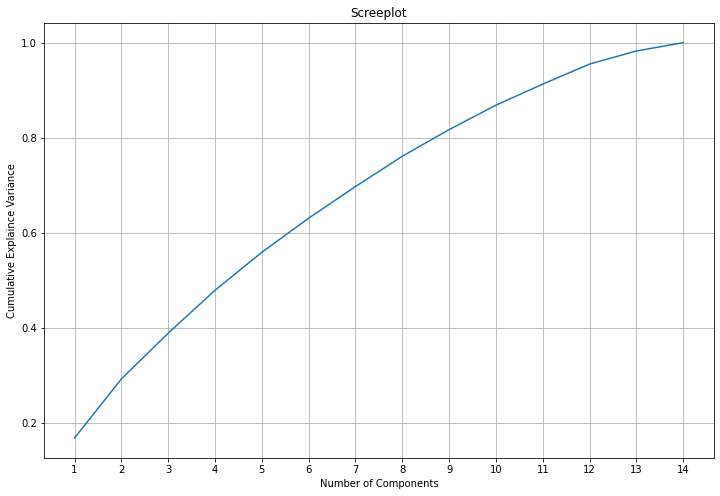

```
First 11 components explain 91.27772% of the variance of the selected features
```

```python
# Apply dimension reduction technique on Train set and get the number of optimal components
X_train, n = dimension_reduction(X_train)

# Initialise PCA
pca = PCA(n_components=n, svd_solver='randomized', random_state=42)

# Transform validation set to the required features learnt from train set to keep them similar
X_val = pd.DataFrame(pca.fit_transform(X_val))
```

###### The cell below achieve the following:-

- Pick up a supervised learning model.
- Train the model.
- Use cross validation techniques. (Calls param_tuning function for this) Hint: Use all CV techniques that you have learnt in the course.
- Apply hyper-parameter tuning techniques to get the best accuracy. (Calls param_tuning function for this) Suggestion: Use all possible hyper parameter combinations to extract the best accuracies.
- Display and explain the classification report in detail.
- Design a method of your own to check if the achieved train and test accuracies might change if a different sample population can lead to new train and test accuracies. (Calls param_tuning function for this) Hint: You can use your concepts learnt under Applied Statistics module.
- Apply the above steps for all possible models that you have learnt so far.